# Reproducible Research PA1

J. Voltz

February 20, 2018

Loading and preprocessing the data

```r
activity <- read.csv("activity.csv", header = T)

# Review
dim(activity)
```

```
## [1] 17568     3
```

```r
str(activity)
```

```
## 'data.frame':    17568 obs. of  3 variables:
##  $ steps   : int  NA NA NA NA NA NA NA NA NA NA ...
##  $ date    : Factor w/ 61 levels "2012-10-01","2012-10-02",..: 1 1 1 1 1 1 1 1 1 1 ...
##  $ interval: int  0 5 10 15 20 25 30 35 40 45 ...
```

Date class and interval factor

```r
activity$date <- as.Date(activity$date, format = "%Y-%m-%d")
activity$interval <- factor(activity$interval)

##missing data
missing_activity<- activity[is.na(activity$steps),]
dim(missing_activity)
```

```
## [1] 2304    3
```

What is the mean total number of steps taken per day?

Calculate the total number of steps taken per day

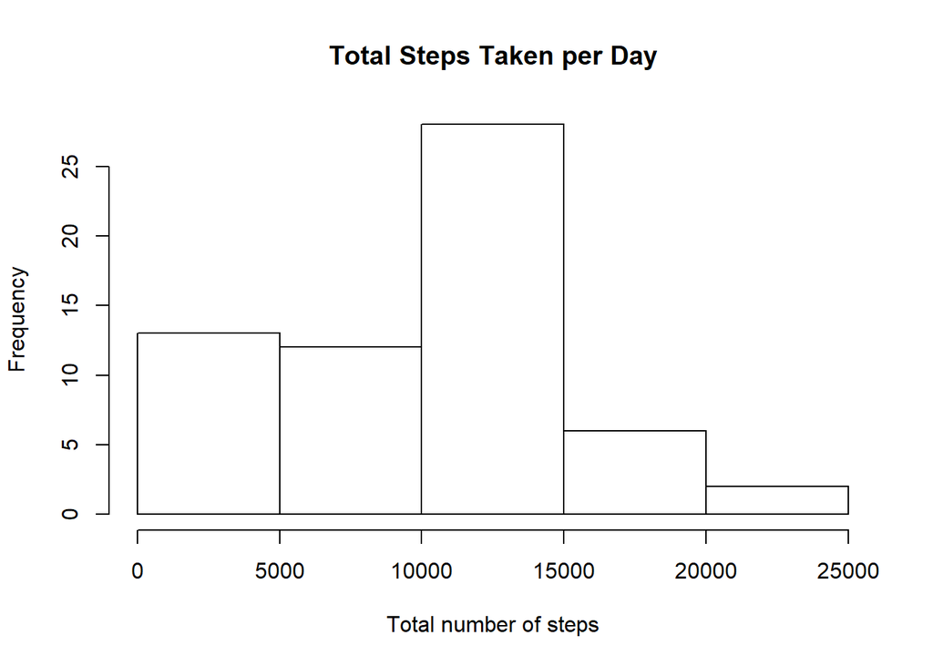

```r
activity1 <- activity[!is.na(activity$steps),]

TotalSteps <- with(activity, tapply(steps, as.factor(activity$date), sum, na.rm = TRUE))

hist(TotalSteps, main = "Total Steps Taken per Day", xlab = "Total number of steps")
```

Calculate and report the mean and median of the total number of steps taken per day

```r
summary(TotalSteps)
```

```
##    Min. 1st Qu.  Median    Mean 3rd Qu.    Max.
##       0    6778   10395    9354   12811   21194
```

What is the average daily activity pattern?

Make a time series plot (i.e. type = “l”) of the 5-minute interval (x-axis) and the average number of steps taken, averaged across all days (y-axis)

```r
mean_steps <- with(activity1, tapply(steps, activity1$interval, mean))
interval<- levels(as.factor(activity$interval))
```

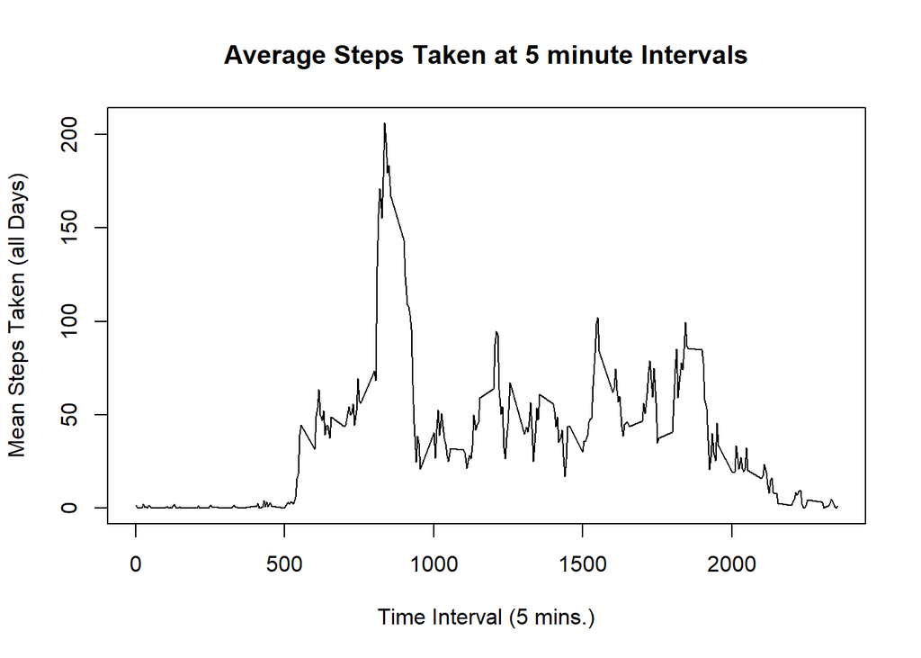

```r
plot(interval, mean_steps, type = "l", xlab = "Time Interval (5 mins.)", ylab = "Mean Steps Taken (all Days)", main = "Average Steps Taken at 5 minute Intervals",  col = "black")
```

Which 5-minute interval, on average across all the days in the dataset, contains the maximum number of steps?

```r
table <- data.frame(mean_steps, interval)
table[table$mean_steps==max(table$mean_steps),][2]
```

```
##     interval
## 835      835
```

Imputing missing values

Calculate and report the total number of missing values in the dataset (i.e. the total number of rows with NAs)

```r
length(missing_activity$steps)
```

```
## [1] 2304
```

Devise a strategy for filling in all of the missing values in the dataset

```r
mean_steps <- with(activity1, tapply(steps, activity1$interval, mean))
missing_activity$steps <- mean_steps
```

Create a new dataset that is equal to the original dataset but with the missing data filled in.

```r
new_activity <- rbind(activity1, missing_activity)
new_activity <- new_activity[order(new_activity$date), ]
```

Make a histogram of the total number of steps taken each day and Calculate and report the mean and median total number of steps taken per day

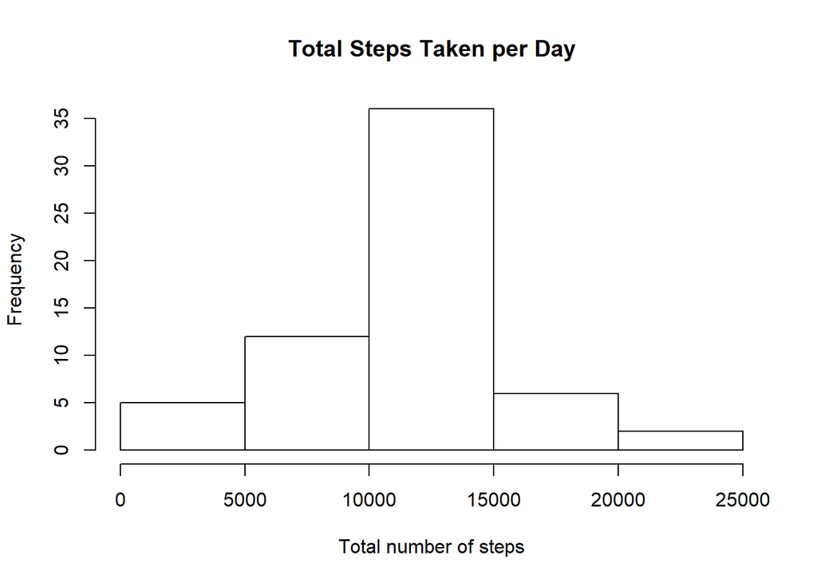

```
Calculate and report the mean and median of the total number of steps taken per day.
```

```r
TotalSteps2 <- with(new_activity, tapply(steps, as.factor(new_activity$date), sum))

hist(TotalSteps2, main = "Total Steps Taken per Day", xlab = "Total number of steps")
```

Mean and median total number of steps taken per day WITHOUT filling in the missing values

```r
##With NA
summary(TotalSteps)
```

```
##    Min. 1st Qu.  Median    Mean 3rd Qu.    Max.
##       0    6778   10395    9354   12811   21194
```

```r
##Without NA
summary(TotalSteps2)
```

```
##    Min. 1st Qu.  Median    Mean 3rd Qu.    Max.
##      41    9819   10766   10766   12811   21194
```

Are there differences in activity patterns between weekdays and weekends?

```r
activity$day <- as.factor(weekdays(activity$date))

activity$is_weekday <- ifelse(!(activity$day %in% c("Saturday","Sunday")), TRUE, FALSE)

weekdays <- activity[activity$is_weekday,]
interval_weekdays <- aggregate(weekdays$steps, by=list(interval=weekdays$interval), FUN=mean)

weekends <- activity[!activity$is_weekday,]
interval_weekends <- aggregate(weekends$steps, by=list(interval=weekends$interval), FUN=mean)

colnames(interval_weekdays) <- c("interval", "avgsteps")
colnames(interval_weekends) <- c("interval", "avgsteps")

interval_weekdays$day <- "Weekday"
interval_weekends$day <- "Weekend"

week <- rbind(interval_weekends, interval_weekdays)

week$day <- as.factor(week$day)
```

Make a panel plot containing a time series plot (i.e. type = “l”) of the 5-minute interval (x-axis) and the average number of steps taken, averaged across all weekday days or weekend days (y-axis)

[figure not shown]

```r
library(lattice)
xyplot(mean_steps ~  interval | day, data = week, layout = c(1,2), type ="l", ylab="Steps")
```